# Q2-R-Project-Group-8

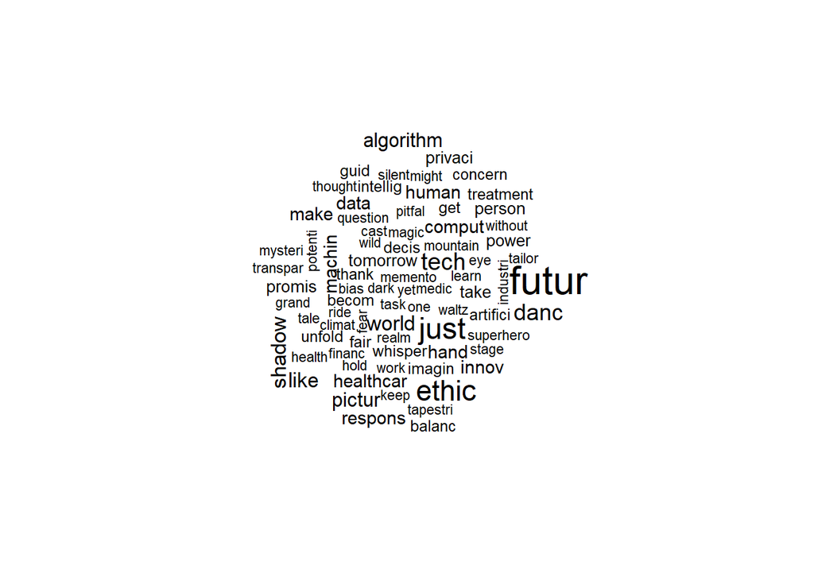

```r
wordcloud(termG2$word,termG2$freq,scale = c(2,0.5))
```

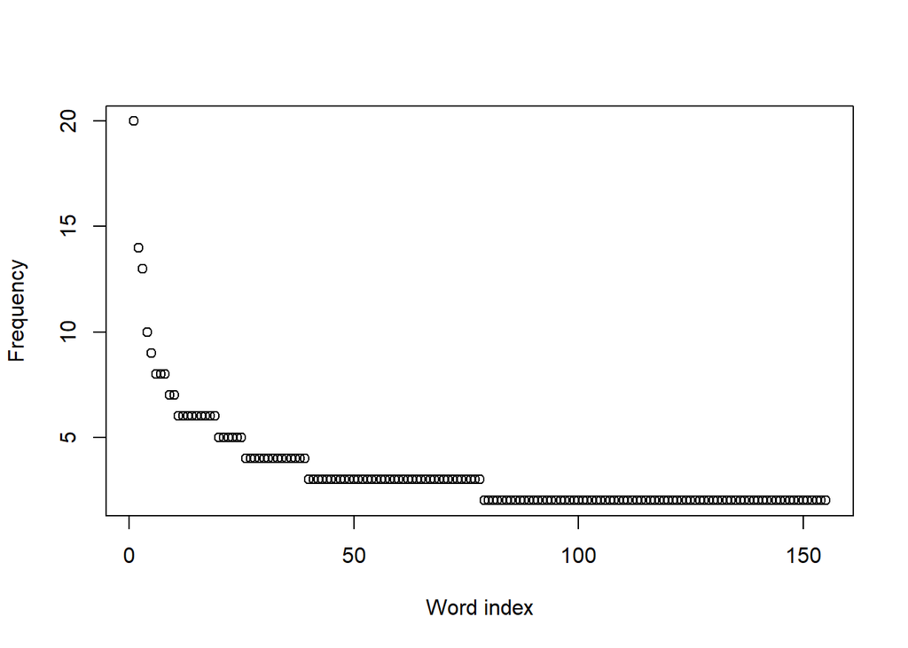

```r
numTermsGte2 <- sum(termG2$freq > 1)
cols <- rainbow(numTermsGte2)
plot(termG2$freq[termG2$freq > 1], xlab = "Word index", ylab = "Frequency")
```

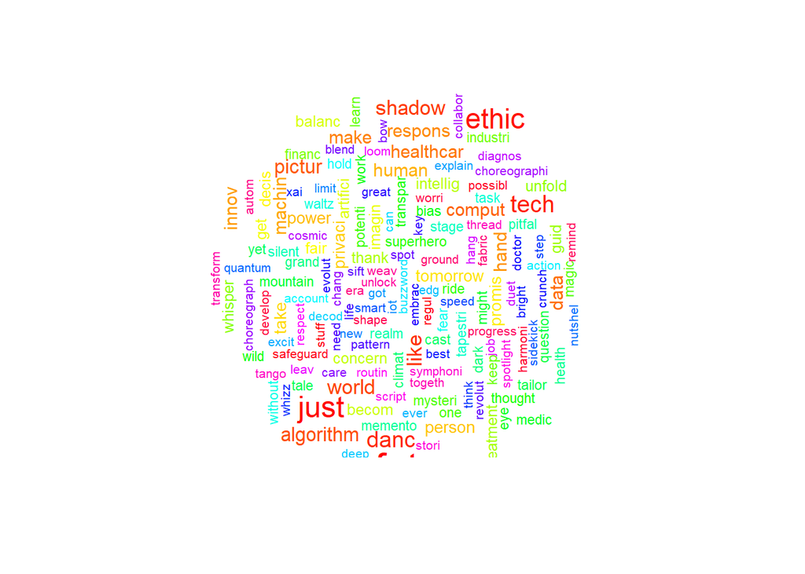

```r
wordcloud(termG2$word[termG2$freq >1], termG2$freq[termG2$freq > 1],scale = c(2,0.5), min.freq = 2, rot.per = .5,colors = cols, random.color = FALSE, ordered.colors = TRUE)
```

## TF-IDF

- **Conduct a TF-IDF analysis to identify the most important terms in the text:** The ten most important terms in the TF-IDF analysis in decreasing order are: computer, human, just, dance, learn, fear, stage, get, tech, and stuff
- **Discuss how these terms contribute to the overall meaning of the text:** These terms help to create a negative meaning in the text such as using words like, fear. These negative terms helps to show bring pull the entire text into a negative meaning against A.I. However their is also terms such that bring out a postitive meaning such as dance and learn. These help to bring the entire text into a positive meaning that supports A.I. Depending how many times the positive and negative terms are used these terms will effect the meaning of the entire text.

```r
tdGM[1:4,1:6]
```

```
##            Docs
## Terms       1 2 3 4 5 6
##   account   1 0 0 0 0 1
##   action    1 0 1 0 0 0
##   algorithm 1 1 3 0 2 0
##   also      1 0 0 0 0 0
```

```r
tfidf <- TermDocumentMatrix(corpG, control = list(weighting = function(x) {weightTfIdf(x)}))
tfidf <- as.matrix(tfidf)
tfidf[1:4,1:6]
```

```
##            Docs
## Terms                 1          2           3 4           5          6
##   account   0.011083654 0.00000000 0.000000000 0 0.000000000 0.01016002
##   action    0.011083654 0.00000000 0.009906016 0 0.000000000 0.00000000
##   algorithm 0.004090647 0.00471744 0.010968047 0 0.009511585 0.00000000
##   also      0.018076661 0.00000000 0.000000000 0 0.000000000 0.00000000
```

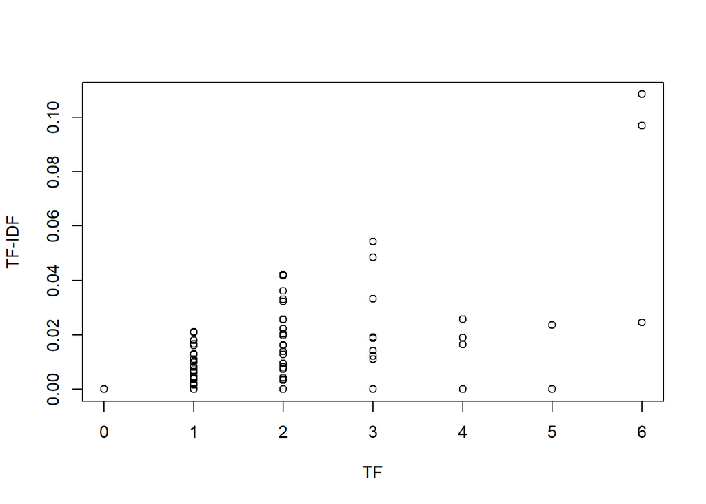

```r
# plot tf values vs tfidf values
tfV <- as.vector(tdGM)
tfidfV <- as.vector(tfidf)
plot(tfV,tfidfV,xlab = "TF", ylab = "TF-IDF")
```

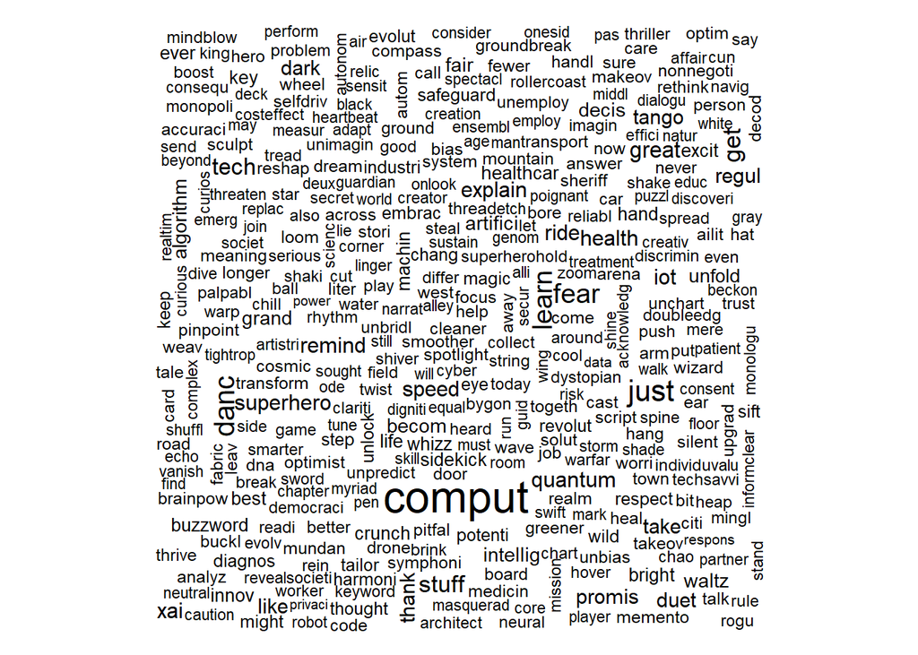

```r
# word cloud on tfidf values
tfidfByWords <-rowSums(tfidf)
wordcloud(rownames(tfidf),tfidfByWords,scale = c(2,0.5))
```

```r
summary(tfidfByWords)
```

```
##    Min. 1st Qu.  Median    Mean 3rd Qu.    Max.
## 0.00000 0.01657 0.01808 0.02087 0.02102 0.10846
```

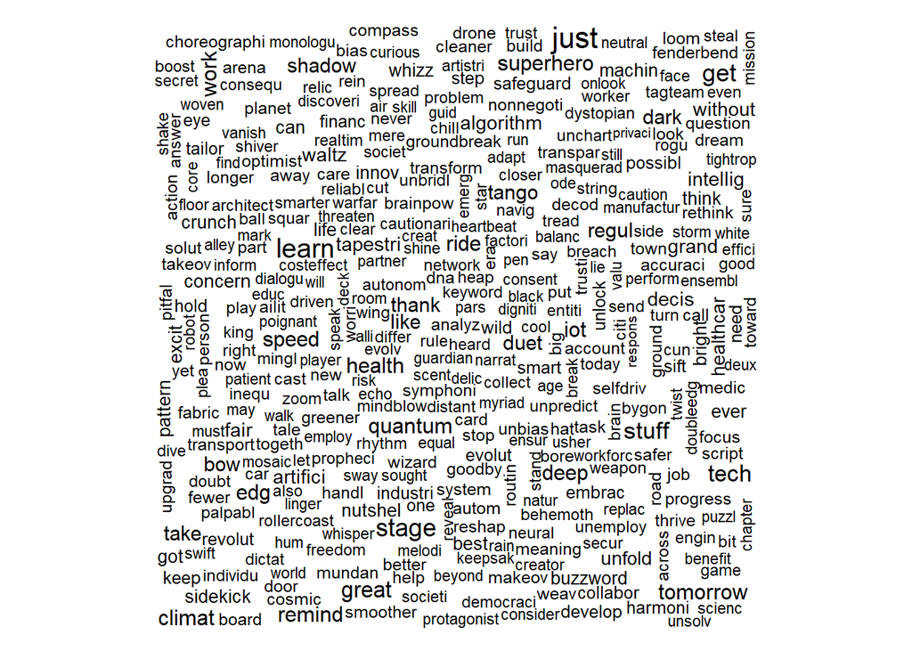

```r
# word cloud based on TFIDF values, min freq
wordcloud(rownames(tfidf),tfidfByWords,scale = c(2,0.5), min.freq = 0.75)
```

```r
# orders words by TFIDF values
orderWords <- order(tfidfByWords, decreasing = TRUE)
tfidfOrder <- tfidf[orderWords,]
rownames(tfidfOrder)[1:10]
```

```
##  [1] "comput" "human"  "just"   "danc"   "learn"  "fear"   "stage"  "get"
##  [9] "tech"   "stuff"
```

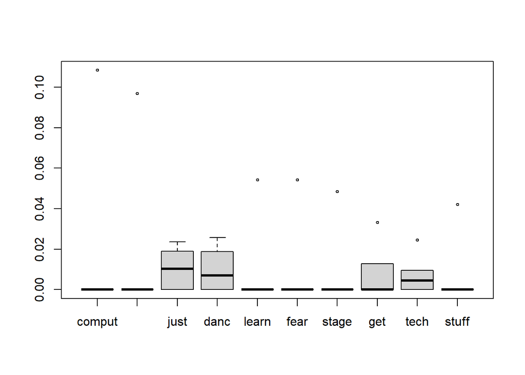

```r
# Create a boxplot of the top 10 TFIDF values
tfidfTr <- t(tfidfOrder)
boxplot(tfidfTr[,1:10],cex = 0.5)
```

```r
dim(tfidfTr)
```

```
## [1]   6 489
```

```r
# dimensions of the transposed matrix
```

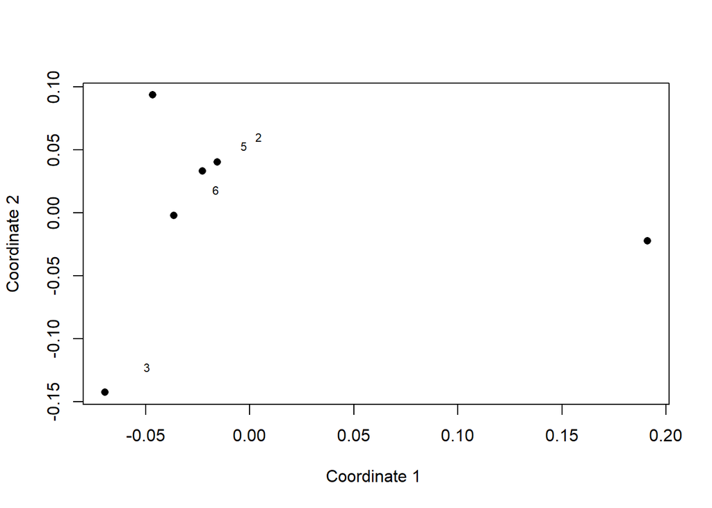

```r
studCodes = df$Number
distdat <- dist(tfidfTr)
# multidimensional scaling and scatter plot
fit <- cmdscale(distdat, k = 2)
plot(fit, pch = 16, xlab = "Coordinate 1 ", ylab = "Coordinate 2")
text(fit +0.02, label = studCodes, cex = 0.7)
```

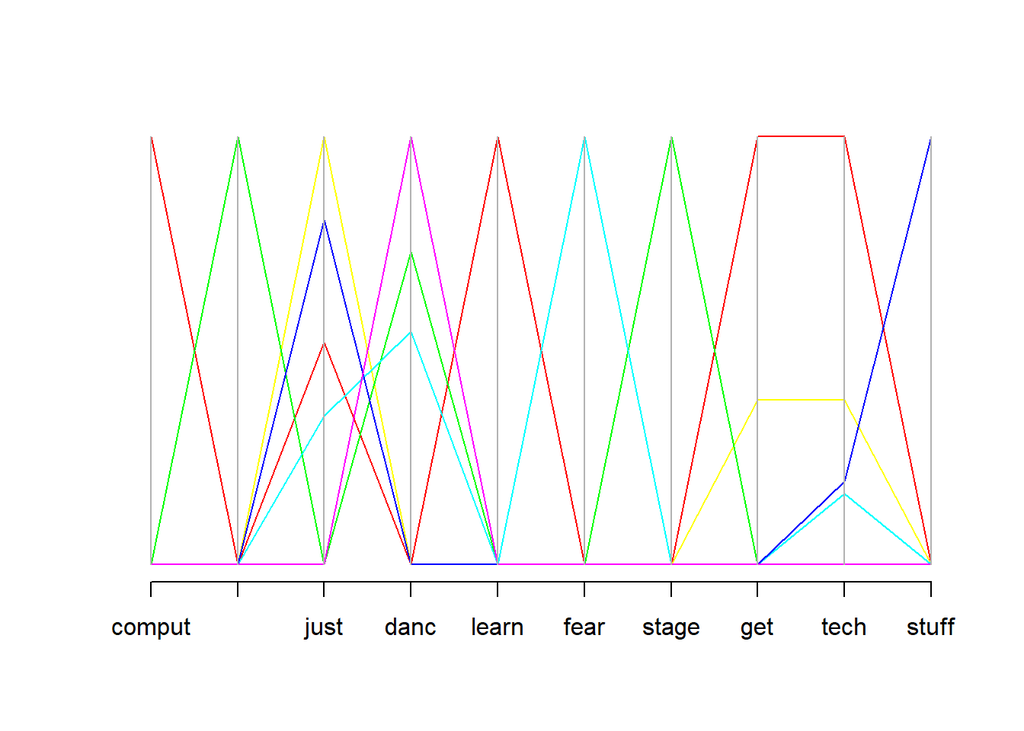

```r
# Parallel coordinates plot
cols <- rainbow(dim(tfidfTr)[[1]])
parcoord(tfidfTr[,1:10],col = cols)
```